# Discrepancy in Cohort and Job Files

Suzanne Dufault

4/20/2020

# Brief Intro to End of Employment Dates

## Original Data Files

There are two places where an employee’s termination date may appear. First, as a part of the YOUT variable in the cohort file. The most recent is the YOUT16 variable in the `auto_vs_15.sas7bdat` file.

First few rows of cohort file

| STUDYNO | YOB | PLANT | YIN16 | YOUT16 | cod_09 | V_ICD | yrin16 |
| --- | --- | --- | --- | --- | --- | --- | --- |
| 100001 | 1942.00 | 3 | 1971.11 | 1995.000 |  | 10 | 1974.11 |
| 100002 | 1953.55 | 2 | 1976.62 | 1995.000 |  | NaN | 1979.62 |
| 100004 | 1912.14 | 1 | 1950.26 | 1980.000 | 431x | 9 | 1953.26 |
| 100005 | 1957.30 | 2 | 1977.32 | 1995.000 |  | NaN | 1980.32 |
| 100006 | 1880.88 | 2 | 1943.66 | 1948.604 | 433x | 9 | 1946.66 |

The second place is in the job files which have one row per transaction rather than per person.

Example rows from a job file.

| YEARS | BIO | CL | EA | DATEIN | DATEOUT | HISTCODE | MACH | FLUID | SF | PCNT | TRZ | MTL1 | MTL2 | S | ALUM | IRON | STEEL | CHR | NO2 | TEA | FILL | STUDYNO | DATEOUT.year |
| --- | --- | --- | --- | --- | --- | --- | --- | --- | --- | --- | --- | --- | --- | --- | --- | --- | --- | --- | --- | --- | --- | --- | --- |
| 1.4127302 |  |  |  | 6277 | 6793 | SR |  |  | NaN | 100 |  |  |  |  |  |  |  |  |  |  | 0 | 102763 | 1978 |
| 0.8432579 | N | N | N | 6793 | 7101 | 118 | AS |  | 1.00 | 100 | N | N |  | N |  |  |  |  | N | N | 0 | 102763 | 1979 |
| 0.5557833 | Y | Y | Y | 7101 | 7304 | 058 | GR | O | 1.50 | 100 | Y | S |  | N |  |  | Y |  | N | N | 0 | 102763 | 1979 |
| 0.2464066 | Y | Y | Y | 7305 | 7395 | 058 | GR | O | 1.00 | 100 | Y | S |  | N |  |  | Y |  | N | N | 0 | 102763 | 1980 |
| 0.6899381 |  |  |  | 7395 | 7647 | OFF |  |  | NaN | 100 |  |  |  |  |  |  |  |  |  |  | 0 | 102763 | 1980 |
| 0.5174537 | N | N | N | 7647 | 7836 | 157 | AS |  | 1.00 | 100 | N | N |  | N |  |  |  |  | N | N | 0 | 102763 | 1981 |
| 2.2614632 |  |  |  | 7836 | 8662 | OFF |  |  | NaN | 100 |  |  |  |  |  |  |  |  |  |  | 0 | 102763 | 1983 |
| 0.3997262 | N | N | N | 8662 | 8808 | 157 | AS |  | 1.00 | 100 | N | N |  | N |  |  |  |  | N | N | 0 | 102763 | 1984 |
| 0.4952223 | N | N | N | 8808 | 9046 | 166 | BM | O | 1.00 | 76 | N | S |  | N |  |  | Y |  | N | N | 0 | 102763 | 1984 |
| 0.1563860 | Y | N | Y | 8808 | 9046 | 166 | GR | Y | 1.00 | 24 | N | S |  | N |  |  | Y |  | N | N | 0 | 102763 | 1984 |
| 0.1163586 | N | N | N | 9046 | 9131 | 168 | AS |  | 1.00 | 50 | N | N |  | N |  |  |  |  | N | N | 0 | 102763 | 1984 |
| 0.1163586 | N | N | N | 9046 | 9131 | 168 | DT | O | 1.00 | 50 | N | S |  | N |  |  | Y |  | N | N | 0 | 102763 | 1984 |
| 0.3047357 | N | N | N | 9132 | 9243 | 168 | AS |  | 1.00 | 50 | N | N |  | N |  |  |  |  | N | N | 1 | 102763 | 1985 |
| 0.3047357 | N | N | N | 9132 | 9243 | 168 | DT | O | 1.00 | 50 | N | S |  | N |  |  | Y |  | N | N | 1 | 102763 | 1985 |
| 0.4024641 | N | N | N | 9243 | 9390 | 560 | AS |  | 1.00 | 100 | N | N |  | N |  |  |  |  | N | N | 0 | 102763 | 1985 |
| 0.0191650 | N | N | N | 9390 | 9397 | 535 | AS |  | 1.00 | 100 | N | N |  | N |  |  |  |  | N | N | 0 | 102763 | 1985 |
| 0.6899384 | N | N | N | 9397 | 9649 | 560 | AS |  | 1.00 | 100 | N | N |  | N |  |  |  |  | N | N | 0 | 102763 | 1986 |
| 0.2518823 | N | N | N | 9649 | 9741 | 626 | AS |  | 1.00 | 100 | N | N |  | N |  |  |  |  | N | N | 0 | 102763 | 1986 |
| 0.1122519 | N | N | N | 9741 | 9782 | 560 | AS |  | 1.00 | 100 | N | N |  | N |  |  |  |  | N | N | 0 | 102763 | 1986 |
| 5.3661876 | N | N | N | 9782 | 11742 | 560 | AS |  | 1.00 | 100 | N | N |  | N |  |  |  |  | N | N | 0 | 102763 | 1992 |
| 0.0766598 | N | N | N | 11742 | 11770 | 583 | AS |  | 1.00 | 100 | N | N |  | N |  |  |  |  | N | N | 0 | 102763 | 1992 |
| 0.2683094 | N | N | N | 11770 | 11868 | 575 | BM | O | 0.39 | 100 | N | I |  | N |  | Y |  |  | N | N | 0 | 102763 | 1992 |
| 0.0574949 | N | N | N | 11868 | 11889 | 575 | BM | O | 0.39 | 100 | N | I |  | N |  | Y |  |  | N | N | 0 | 102763 | 1992 |
| 0.0383299 |  |  |  | 11889 | 11903 | OFF |  |  | NaN | 100 |  |  |  |  |  |  |  |  |  |  | 0 | 102763 | 1992 |
| 0.2683094 | N | N | N | 11903 | 12001 | 575 | BM | O | 0.39 | 100 | N | I |  | N |  | Y |  |  | N | N | 0 | 102763 | 1992 |
| 0.0766598 | N | N | N | 12001 | 12029 | 575 | BM | O | 0.39 | 100 | N | I |  | N |  | Y |  |  | N | N | 0 | 102763 | 1992 |
| 0.1916496 | N | N | N | 12029 | 12099 | 595 | AS |  | 1.00 | 100 | N | N |  | N |  |  |  |  | N | N | 0 | 102763 | 1993 |
| 0.0958248 | N | N | N | 12099 | 12134 | 595 | AS |  | 1.00 | 100 | N | N |  | N |  |  |  |  | N | N | 0 | 102763 | 1993 |
| 0.9418207 | N | N | N | 12134 | 12478 | 595 | AS |  | 1.00 | 100 | N | N |  | N |  |  |  |  | N | N | 0 | 102763 | 1994 |
| 0.0000000 |  |  |  | 12478 | 12478 | OFF |  |  | NaN | 100 |  |  |  |  |  |  |  |  |  |  | 0 | 102763 | 1994 |
| 0.0000000 |  |  |  | 12478 | 12478 | OFF |  |  | NaN | 100 |  |  |  |  |  |  |  |  |  |  | 0 | 102763 | 1994 |

## Distribution of Discrepancy

They are not clean, there are duplicates, and we recently discovered that a number of the job records have the following odd property. Usually, if the last job record has DATEIN = DATEOUT, that is considered the end of employment for that employee.

Out of the 29549 whose YOUT16 occurred after 1970, 2004 have YOUT16s more than 2 years prior to their final job DATEOUT (using 2 years as a reasonable margin of error).

Specifically, the distribution of the discrepancy looks like this:

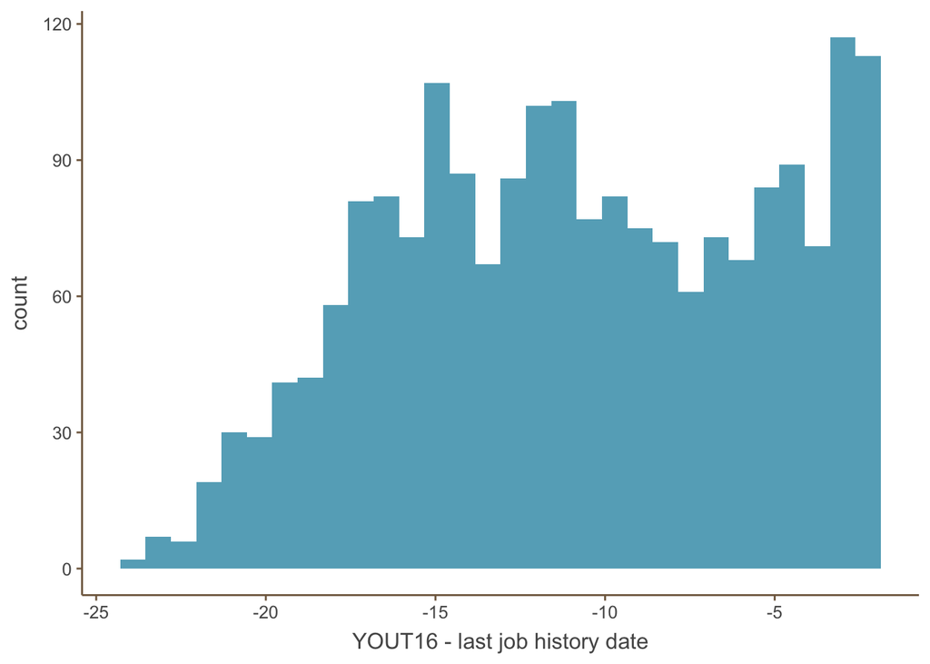

## Discrepancy Pattern

If we look at the last three entries for most of these individuals, we see an odd pattern:

[output not shown]

Not all, but many of the individuals have two “OFF” records with one occurring far earlier than the other.